# Analiza filmów: projekt

# Wstęp

Na stronach z rankingami filmów istnieje często prosty system wystawiania noty danej produkcji - spośród wszystkich ocen nadsyłanych przez użytkowników ustalna jest pewna próbka, z której liczona zostaje średnia. Taki system obowiązuje m.in. na polskim największym portalu filmowym, czyli Filmwebie. O ocenie decydują ludzie, którzy seans mają już za sobą, albo postanowili wystawić ocenę bez zaznajomienia się z filmem. Z kolei serwis Metacritic posługuje się ocenami profesjonalnych recenzentów, jednak mimo to jest to wciąż ta sama metoda jak ta ukazana wyżej, tylko z wykluczeniem opcji wystawiania not bez uzasadnienia.

Reasumując, średnia jest nieodzownym elementem wystawiania ocen filmom. W niniejszym projekcie jednak zaproponowane zostanie inne podejście, próbujące wyjaśnić ocenę danej produkcji nie za pomocą opinii widzów, a parametrów filmu. Projekt skupiać się będzie w głównej mierze na eksploracyjnej analizie danych, jednak nie zabraknie w nim tworzenia modeli opisujących ocenę filmu.

# 1. Zebranie danych

Wykorzystana w niniejszym opracowaniu baza danych bazuje na dwóch serwisach filmowych: IMDB (z tej strony pochodzą tytuły filmów wraz z podanym gatunkiem, nazwiska reżyserów i aktorów biorących udział w produkcji, a także czas trwania filmu oraz jego boxoffice) oraz Filmweb (stąd pobrane zostały oceny gry aktorskiej aktorów i akorek, a także reżyserów, oraz liczba zdobytych przez film Oscarów).

Baza danych z IMDB została pobrana ze strony Kaggle (https://www.kaggle.com/PromptCloudHQ/imdb-data/version/1). Baza ta obejmuje 1000 najpopularniejszych filmów na portalu IMDB w latach 2008-2016. Dodatkowo, z wykorzystaniem programu R, przygotowano trzy ramki danych dotyczące aktorów, aktorek i reżyserów (ze względu na obszerność kodu oraz małe znaczenie w procesie analizy, kod źródłowy nie zostanie zamieszczony). Za pomocą webscrappingu pobrano z topki Filmwebu rankingi wyżej wymienionych osób (obejmuje ona 100 reżyserów, 500 aktorów i 375 aktorek). Każdą ramkę po kolei łączono z bazą IMDB na podstawie klucza w postaci imienia i nazwiska aktora/aktorki/reżysera. Po dokonanych operacjach w bazie zostały 122 kompletne rekordy (845 filmów zostało usuniętych przez brak oceny reżysera, a następne 33 przez brak oceny głównego aktora/aktorki). Uzyskanym filmom przypisano następnie liczbę zdobytych Oscarów, posługując się portalem Filmweb oraz listą nagrodzonych filmów z Wikipedii.

Uzyskane finalnie dane mają następującą strukturę:

```python
import pandas as pd
import matplotlib.pyplot as plt
import numpy as np
import seaborn as sns

filmy = pd.read_csv("C:/Users/Jan/Desktop/filmy.csv", sep=';')

filmy.info()
```

```
<class 'pandas.core.frame.DataFrame'>
RangeIndex: 122 entries, 0 to 121
Data columns (total 11 columns):
Aktor             122 non-null object
Rezyser           122 non-null object
Tytul             122 non-null object
Gatunek           122 non-null object
Dlugosc           122 non-null int64
Ocena             122 non-null float64
Glosy             122 non-null int64
Box.office        122 non-null float64
Ocena_rezysera    122 non-null float64
Ocena_aktora      122 non-null float64
Oscary            122 non-null int64
dtypes: float64(4), int64(3), object(4)
memory usage: 10.6+ KB
```

Jak zostało wspomniane wcześniej, w bazie danych znajdują się 122 filmy. W zbiorze brak jest brakujących obserwacji. Kilka rekordów, które posiadały brakującą wartość dla zmiennej Box.office, zostało uzupełnionych ręcznie. Znaczenie poszczególnych zmiennych jest następujące:

- Aktor - imię i nazwisko aktora/aktorki odgrywających główną rolę w filmie (oryginalnie w bazie wymienionych było przypisanych kilku aktorów do jednego filmu, w celu uproszczenia jednak pozostawiono tylko jednego z nich)
- Rezyser - imię i nazwisko reżysera filmu
- Tytul - tytuł filmu
- Gatunek - gatunek (bądź gatunki) filmu
- Dlugosc - podany w minutach czas trwania filmu
- Ocena - ocena filmu w skali 1-10 (zmienna objaśniana)
- Glosy - liczba głosów oddanych na daną produkcję
- Box.office - przychód ze sprzedaży filmu, liczony w milionach dolarów
- Ocena_rezysera - ocena reżysera filmu w skali 1-10
- Ocena_aktora - ocena głównego aktora/aktorki filmu w skali 1-10
- Oscary - liczba zdobytych przez film Oscarów

Ponieważ wyżej zaprezentowany został wstępny zarys opracowywanych danych, można przejść do następnej części projektu. W tym miejscu mógłby pojawić się też podział zbioru danych na treningowy i testowy. Ponieważ jednak wymogu takiego nie było w wytycznych projektu, zdecydowano się utworzyć modele na całości danych, a następnie poddać je sprawdzianowi krzyżowemu i w ten właśnie sposób zweryfikować słuszność konstruowanych modeli.

# 2. Eksploracyjna analiza danych i Inżynieria Cech

Inżynieria cech będzie prowadzona wraz z eksploracyjną analizą danych, co pozwoli na natychmiastowe wychwycenie pomysłów na nowe zmienne dla przyszłych modeli. Ostatni rzut oka na dane:

```python
filmy.info()
```

```
<class 'pandas.core.frame.DataFrame'>
RangeIndex: 122 entries, 0 to 121
Data columns (total 11 columns):
Aktor             122 non-null object
Rezyser           122 non-null object
Tytul             122 non-null object
Gatunek           122 non-null object
Dlugosc           122 non-null int64
Ocena             122 non-null float64
Glosy             122 non-null int64
Box.office        122 non-null float64
Ocena_rezysera    122 non-null float64
Ocena_aktora      122 non-null float64
Oscary            122 non-null int64
dtypes: float64(4), int64(3), object(4)
memory usage: 10.6+ KB
```

Ponieważ liczba zmiennych nie jest aż tak duża, możliwe będzie przyglądnięcię się każdej z nich z osobna, idąc od góry do dołu listy. Na początku jednak zostanie omówiona zmienna objaśniana.

## 2.1 Ocena + Tytul

Zanim zbada się zależności zmiennej objaśnianej ze zmiennymi objaśnianymi, wartym sprawdzenia jest rozkład ocen filmu. Ukazany zostanie on poniżej. Ponieważ zmienna Tytul jest zmienną ściśle powiązaną ze zmienną Ocena i sama w sobie nie niesie żadnych informacji, niniejszy podrozdział skupi się na wskazanym w podtytule połączeniu.

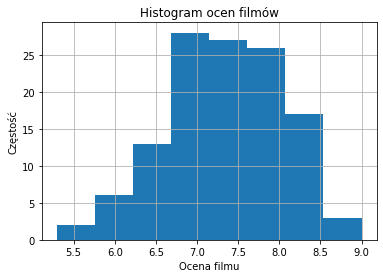

```python
filmy['Ocena'].hist(bins=8)
plt.title("Histogram ocen filmów")
plt.xlabel('Ocena filmu')
plt.ylabel('Częstość')
```

Zauważyć można, że rozkład ocen jest dość równomierny. Rozkład normalny zaburzają filmy z oceną przekraczającą średnią, których jest dość sporo. Wybitnych filmów jest jednak mniej więcej tyle samo, co filmów najsłabszych. Pamiętać jednak należy, że wszystkie filmy ze stawki są jednymi z najlepszych filmów i tak naprawdę nie ma tu wyraźnie słabych produkcji. Mimo to, wynik poniższego wykresu pudełkowego sugeruje, że niektóre z filmów nie dorastają do pięt pozostałym.

|  | Aktor | Rezyser | Tytul | Gatunek | Dlugosc | Ocena | Glosy | Box.office | Ocena_rezysera | Ocena_aktora | Oscary |
| --- | --- | --- | --- | --- | --- | --- | --- | --- | --- | --- | --- |
| 11 | Chris Hemsworth | Michael Mann | Blackhat | Crime,Drama,Mystery | 133 | 5.4 | 43085 | 7.10 | 7.95 | 8.35 | 0 |
| 71 | Michael Fassbender | Ridley Scott | The Counselor | Crime,Drama,Thriller | 117 | 5.3 | 84927 | 16.97 | 7.93 | 8.17 | 0 |

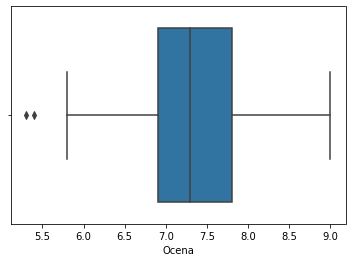

```python
sns.boxplot(filmy['Ocena'])
filmy.loc[filmy['Ocena']<5.5]
```

Wskazane filmy kryminalne odstają od reszty, więc rozważyć będzie trzeba usunięcie ich ze zbioru danych. Ponieważ poznaliśmy już filmy najgorsze, warto też zapoznać się z filmami najlepszymi.

```python
filmy.iloc[filmy['Ocena'].sort_values(ascending=False).head(5).index]
```

|  | Aktor | Rezyser | Tytul | Gatunek | Dlugosc | Ocena | Glosy | Box.office | Ocena_rezysera | Ocena_aktora | Oscary |
| --- | --- | --- | --- | --- | --- | --- | --- | --- | --- | --- | --- |
| 18 | Christian Bale | Christopher Nolan | The Dark Knight | Action,Crime,Drama | 152 | 9.0 | 1791916 | 533.32 | 8.71 | 8.68 | 2 |
| 61 | Leonardo DiCaprio | Christopher Nolan | Inception | Action,Adventure,Sci-Fi | 148 | 8.8 | 1583625 | 292.57 | 8.71 | 8.97 | 4 |
| 69 | Matthew McConaughey | Christopher Nolan | Interstellar | Adventure,Drama,Sci-Fi | 169 | 8.6 | 1047747 | 187.99 | 8.71 | 8.71 | 1 |
| 15 | Christian Bale | Christopher Nolan | The Dark Knight Rises | Action,Thriller | 164 | 8.5 | 1222645 | 448.13 | 8.71 | 8.68 | 0 |
| 59 | Leonardo DiCaprio | Martin Scorsese | The Departed | Crime,Drama,Thriller | 151 | 8.5 | 937414 | 132.37 | 8.60 | 8.97 | 4 |

Pozycja reżysera wygląda dość monotematycznie w powyższym zestawieniu. Na tą chwilę jednak ważnym do zaznaczenia jest fakt, że czołówka stawki wygląda dość imponująco pod względem wszyskich zmiennych (może z wyjątkiem liczby Oscarów dla jednego z filmów z Batmanem). Pewnym jest, że ukazane filmy jeszcze nie raz ukażą się przy dalszej analizie. Póki co jednak należy zbadać powiązanie zmiennej Ocena z pozostałymi zmiennymi modelu.

## 2.2 Aktor + Ocena_aktora

Podobnie jak sam film, aktor grający w nim główną rolę też ma swoją parę, którą jest zmienna Ocena_aktora. Na początek warto sprawdzić, jak wygląda czołówka liczby wystąpień. Który z aktorów może liczyć na największą powtarzalność w wybranych najlepszych produkcjach?

```python
len(filmy['Aktor'].unique())
```

```
75
```

```python
filmy['Aktor'].value_counts().head(10)
```

```
Christian Bale       6
Leonardo DiCaprio    6
Johnny Depp          5
Tom Hanks            4
Denzel Washington    4
Daniel Craig         3
Brad Pitt            3
Russell Crowe        3
Sharlto Copley       2
Hugh Jackman         2
Name: Aktor, dtype: int64
```

W bazie znajduje się 75 unikalnych aktorów. Niewielu spośród nich ma jednak na koncie parę wystąpień. W czołówce na pierwszym miejscu znajdują się ex aequo Christian Bale i Leonardo DiCaprio. W ukazanej stawce nie znajduje się jednak żadna z aktorek. Możliwe jednak, że znajdzie się nie w częstości wystąpień, a w rankingu najlepszych aktorów.

```python
filmy[['Aktor','Ocena_aktora']].drop_duplicates().nlargest(10,'Ocena_aktora')
```

|  | Aktor | Ocena_aktora |
| --- | --- | --- |
| 48 | Joaquin Phoenix | 9.14 |
| 59 | Leonardo DiCaprio | 8.97 |
| 21 | Clint Eastwood | 8.88 |
| 77 | Robert Downey Jr. | 8.88 |
| 91 | Tom Hanks | 8.86 |
| 39 | Ian McKellen | 8.82 |
| 95 | Tom Hardy | 8.80 |
| 26 | Daniel Day-Lewis | 8.78 |
| 49 | Johnny Depp | 8.78 |
| 33 | Geoffrey Rush | 8.71 |

Niestety, również w tym przypadku nie można odnaleźć żadnej aktorki. Większość nazwisk wygląda znajomo, kiedy popatrzymy na wcześniejszą tabelę z liczbą wystąpień. Jak jednak ocena gry aktorskiej wygląda w ujęciu całościowym, w relacji do ocen filmów? Czy zasięg wartości jest podobny?

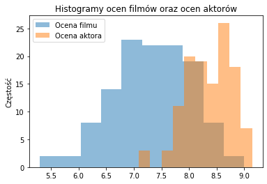

```python
plt.hist(filmy['Ocena'], bins=10, alpha=0.5, label='Ocena filmu')
plt.hist(filmy['Ocena_aktora'], bins=10, alpha=0.5, label='Ocena aktora')
plt.legend(loc='upper left')
plt.title("Histogramy ocen filmów oraz ocen aktorów")
plt.ylabel('Częstość')
plt.show()
```

Wyrażnie widać różnice w rozkładzie obu zmiennych. Aktorzy są oceniani znacznie hojniej w skali 1-10. Gdyby jednak przesunąć nieco rozkład ocen aktorów, pokryłby się on z rozkładem ocen filmów. Również u aktorów można mówić o dużej koncentracji wokół średniej, a także niewielką liczbą słabszych obiektów. Patrząc na histogram można odnieść wrażenie, że za outlier można uznać aktorów znajdujących się w pojedynczym słupku przy wartości 7. Przypuszczenie to potwierdzić może wykres pudełkowy.

|  | Aktor | Rezyser | Tytul | Gatunek | Dlugosc | Ocena | Glosy | Box.office | Ocena_rezysera | Ocena_aktora | Oscary |
| --- | --- | --- | --- | --- | --- | --- | --- | --- | --- | --- | --- |
| 103 | Charlotte Gainsbourg | Lars von Trier | Nymphomaniac: Vol. II | Drama | 123 | 6.7 | 65824 | 0.33 | 7.7 | 7.09 | 0 |
| 104 | Charlotte Gainsbourg | Lars von Trier | Nymphomaniac: Vol. I | Drama | 117 | 7.0 | 90556 | 0.79 | 7.7 | 7.09 | 0 |

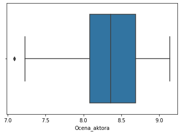

```python
sns.boxplot(filmy['Ocena_aktora'])
filmy.loc[filmy['Ocena_aktora']<7.1]
```

```python
(filmy['Aktor'] == 'Charlotte Gainsbourg').sum()
```

```
2
```

Wniosek jest następujący: obie części Nimfomanki odstają na poziomie aktorskim. Aktorka grająca w tych produkcjach nie występuje w pozostałych filmach ze zbioru danych. Aktorka jest jednak wciąż oceniana lepiej niż sam film, który uplasował się mniej więcej w połowie stawki. Czy istnieją zatem filmy, które mimo słabej gry aktorskiej uzyskały dobre noty? Albo miały świetny potencjał w postaci doborowej obsady aktorskiej, a sam film wyszedł mierny?

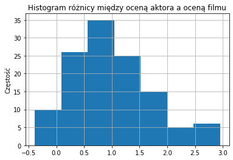

```python
roznice_aktorskie = filmy['Ocena_aktora'] - filmy['Ocena']
roznice_aktorskie.hist(bins=7)
plt.title("Histogram różnicy między oceną aktora a oceną filmu")
plt.ylabel('Częstość')
plt.show()
```

Jak widać na histogramie, do rzadkości należała sytuacja, gdy film oceniany był lepiej niż aktor. Miało to miejsce m.in. w następującyh filmach:

```python
roznice_aktorskie_ind = roznice_aktorskie.sort_values(ascending=False).index
filmy[['Tytul','Ocena','Aktor','Ocena_aktora']].iloc[roznice_aktorskie_ind].tail(5)
```

|  | Tytul | Ocena | Aktor | Ocena_aktora |
| --- | --- | --- | --- | --- |
| 87 | District 9 | 8.0 | Sharlto Copley | 7.85 |
| 101 | Arrival | 8.0 | Amy Adams | 7.83 |
| 18 | The Dark Knight | 9.0 | Christian Bale | 8.68 |
| 73 | Whiplash | 8.5 | Miles Teller | 8.12 |
| 46 | Django Unchained | 8.4 | Jamie Foxx | 8.01 |

Co ciekawe, najlepszy film w bazie znajduje się w tym zestawieniu. Jak prezentuje się czołówka drugiej strony tabeli?

```python
filmy[['Tytul','Ocena','Aktor','Ocena_aktora']].iloc[roznice_aktorskie_ind].head(5)
```

|  | Tytul | Ocena | Aktor | Ocena_aktora |
| --- | --- | --- | --- | --- |
| 11 | Blackhat | 5.4 | Chris Hemsworth | 8.35 |
| 71 | The Counselor | 5.3 | Michael Fassbender | 8.17 |
| 81 | Noah | 5.8 | Russell Crowe | 8.52 |
| 13 | Exodus: Gods and Kings | 6.0 | Christian Bale | 8.68 |
| 92 | Inferno | 6.2 | Tom Hanks | 8.86 |

W stawce znajdują się dość znane nazwiska. Wygląda na to, że widzom mógł nie spodobać się zamysł na scenariusz filmu, albo zawiódł jeden z innych aspektów. Czy jednak w ogóle istnieje jakaś korelacja między oceną filmu a oceną aktora w nim grającego?

```
array([[1.        , 0.22673959],
       [0.22673959, 1.        ]])
```

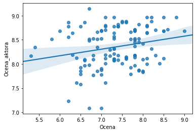

```python
sns.regplot(filmy['Ocena'], filmy['Ocena_aktora'])
np.corrcoef(filmy['Ocena'], filmy['Ocena_aktora'])
```

Otóż niekoniecznie. Wygląda na to, że ocena aktora grającego główne skrzypce niekoniecznie przekładać musi się na ocenę filmu. Widocznie są ważniejsze aspekty, którym może być kolejna omawiana zmienna.

## 2.3 Rezyser + Ocena_rezysera

Jeśli nie aktor, to może reżyser jest tym, kto pozwala przypuszczać ocenę filmu? Podobnie jak u aktorów, na początku warto sprawdzić ich różnorodność w pozyskanej bazie danych.

```python
len(filmy['Rezyser'].unique())
```

```
48
```

```python
filmy['Rezyser'].value_counts().head(10)
```

```
Ridley Scott         8
Christopher Nolan    5
Clint Eastwood       4
Tim Burton           4
Denis Villeneuve     4
Martin Scorsese      4
Peter Jackson        4
Quentin Tarantino    4
Danny Boyle          4
Guy Ritchie          4
Name: Rezyser, dtype: int64
```

Wygląda na to, że świat najlepszych reżyserów jest bardziej zamknięty niż świat najlepszych aktorów. Mnie jest unikalnych pozycji, a po czołówce tabeli widać, że skala udziału w filmach jest też większa niż u aktorów. Pamiętajmy jednak, że w projekcie tym przedstawiony zostaje tylko pewien wycinek rzeczywistości.

W przypadku ocen reżyserów również mamy do czynienia ze skalą 1-10, więc istnieje możliwość, że także w tym przypadku skala nie będzie pokrywać się z ocenami filmów. Pozostaje to sprawdzić na histogramie.

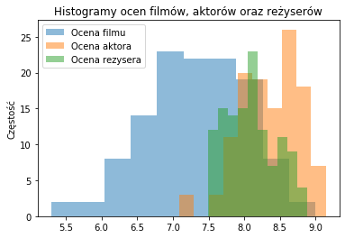

```python
plt.hist(filmy['Ocena'], bins=10, alpha=0.5, label='Ocena filmu')
plt.hist(filmy['Ocena_aktora'], bins=10, alpha=0.5, label='Ocena aktora')
plt.hist(filmy['Ocena_rezysera'], bins=10, alpha=0.5, label='Ocena rezysera')
plt.legend(loc='upper left')
plt.title("Histogramy ocen filmów, aktorów oraz reżyserów")
plt.ylabel('Częstość')
plt.show()
```

Krakowskim targiem, oceny reżyserów zdecydowały się pozostać między oboma skalami. Wygląd histogramu jest jednak inny niż w przypadku konkurencyjnych zmiennych: oceny nie są tak scentralizowane, gromadząc się wokół niższych wartości. Oznaczałoby to, że bycie przeciętnym.dobrym reżyserem jest trudniejsze, niż bycie przeciętnym/dobrym aktorem bądź filmem. Sugerować to może decydującą rolę reżysera przy komponowaniu całości filmu (tak jest w rzeczywistości). Co na oceny reżyserów powie wykres pudełkowy? Czy reżyserzy dobrze oceniani mogą zostać uznani za obserwacje odstające?

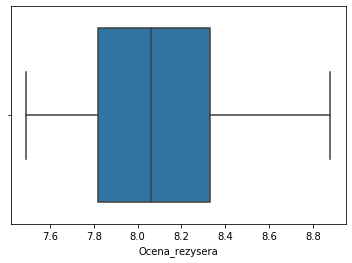

```python
sns.boxplot(filmy['Ocena_rezysera'])
```

Okazuje się, że nie. W przypadku reżyserów wykres pudełkowy wygląda bardzo przyjaźnie. Czy tak samo przyjaźnie będzie wyglądać wykres zależności oceny reżysera od oceny filmu/aktora?

```
array([[1.        , 0.48951391],
       [0.48951391, 1.        ]])
```

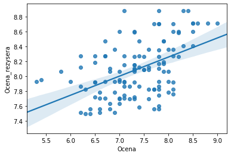

```python
sns.regplot(filmy['Ocena'], filmy['Ocena_rezysera'])
np.corrcoef(filmy['Ocena'], filmy['Ocena_rezysera'])
```

W tym przypadku możemy mówić o średniej korelacji, wygląda to znacznie lepiej niż w przypadku aktorów.

```
array([[1.       , 0.2918468],
       [0.2918468, 1.       ]])
```

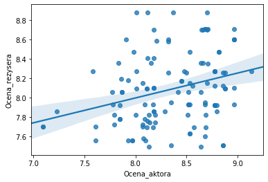

```python
sns.regplot(filmy['Ocena_aktora'], filmy['Ocena_rezysera'])
np.corrcoef(filmy['Ocena_aktora'], filmy['Ocena_rezysera'])
```

Między reżyserem a aktorem stara wojna wiecznie trwa. Jest to jednak wojna z pozytywnym wynikiem, bo wysoka korelacja między zmiennymi objaśnianymi nie jest pożądana.

Jak się ma ocena reżysera do oceny tworzonego przez niego filmu? Podobne badanie było wykonane dla aktora, więc warto wykonać analogiczną czynność dla reżysera właśnie.

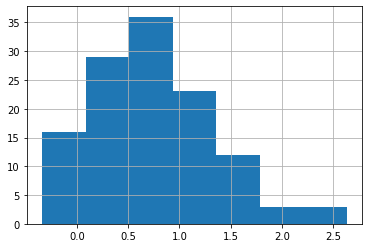

```python
roznice_rezyserskie = filmy['Ocena_rezysera'] - filmy['Ocena']
roznice_rezyserskie.hist(bins=7)
```

Całość wygląda podobnie jak w porpzednim wypadku. Histogram sugeruje jednak, że ujemne różnice nie są tak duże, ponieważ przedział nie sięga do wartości -0.5. Kto zatem przewodzi stawce?

```python
roznice_rezyserskie_ind = roznice_rezyserskie.sort_values(ascending=False).index
filmy[['Tytul','Ocena','Rezyser','Ocena_rezysera']].iloc[roznice_rezyserskie_ind].tail(5)
```

|  | Tytul | Ocena | Rezyser | Ocena_rezysera |
| --- | --- | --- | --- | --- |
| 87 | District 9 | 8.0 | Neill Blomkamp | 7.78 |
| 108 | Atonement | 7.8 | Joe Wright | 7.56 |
| 97 | No Country for Old Men | 8.1 | Ethan Coen | 7.82 |
| 18 | The Dark Knight | 9.0 | Christopher Nolan | 8.71 |
| 65 | Spotlight | 8.1 | Tom McCarthy | 7.76 |

Zarówno District 9 jak i The Dark Knight znajdują się w obu czołówkach. Wygląda na to, że są to filmy szczególnie udane, mimo niekoniecznie tak wysokich ocen reżysera oraz głównego aktora.

```python
filmy[['Tytul','Ocena','Rezyser','Ocena_rezysera']].iloc[roznice_rezyserskie_ind].head(5)
```

|  | Tytul | Ocena | Rezyser | Ocena_rezysera |
| --- | --- | --- | --- | --- |
| 71 | The Counselor | 5.3 | Ridley Scott | 7.93 |
| 11 | Blackhat | 5.4 | Michael Mann | 7.95 |
| 81 | Noah | 5.8 | Darren Aronofsky | 8.06 |
| 52 | Dark Shadows | 6.2 | Tim Burton | 8.27 |
| 13 | Exodus: Gods and Kings | 6.0 | Ridley Scott | 7.93 |

Z kolei druga strona jest praktycznie identyczna. Można tu mówić o wielkich przegranych z jeszcze większym potencjałem.

Aktorzy i reżyserzy to również prawdziwi ludzie, nie tylko ci widziani na ekranie lub w napisach końcowych. Jeśli będzie sięim dobrze współpracowało, mogą chcieć tą współpracę powtórzyć. Odpowiednim krokiem będzie zbadanie duetów aktorsko-reżyserskich i ich wpływu na średnią ocenę filmu. Okazać się może, że stopień znajomości wpływać może na owocną współpracę przy kreowaniu kolejnego hitu kinowego. Do dzieła zatem!

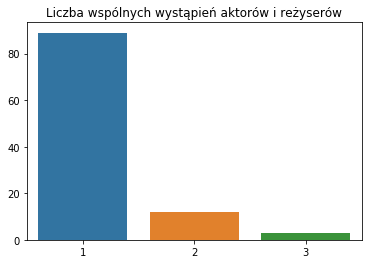

```python
duety = (filmy['Rezyser'] + ' + ' + filmy['Aktor']).value_counts()

sns.countplot(duety)
plt.title("Liczba wspólnych wystąpień aktorów i reżyserów")
plt.ylabel("")
plt.show()
```

Wygląda na to, że niewiele jest takich duetów. Są jednak pary, które szczególnie gorliwie ze sobą współpracowały. Oto one:

```python
duety.head(5)
```

```
Gore Verbinski + Johnny Depp           3
Christopher Nolan + Christian Bale     3
Martin Scorsese + Leonardo DiCaprio    3
Sam Mendes + Daniel Craig              2
Peter Jackson + Ian McKellen           2
dtype: int64
```

```
 <a list of 2 Text xticklabel objects>)
```

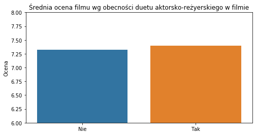

```python
duety = pd.DataFrame(duety.loc[duety>1])
duety['Duet'] = duety.index
czy_duet = []
for i in range(0,len(filmy.index)):
    if ((filmy['Rezyser'][i] + ' + ' + filmy['Aktor'][i]) in duety['Duet']):
        czy_duet.append(1)
    else:
        czy_duet.append(0)

czy_duet = pd.Series(czy_duet)

plt.figure(figsize=(8, 4))
sns.barplot(filmy['Ocena'].groupby(czy_duet).mean().index,
        filmy['Ocena'].groupby(czy_duet).mean())
plt.ylim(6,8)
plt.title("Średnia ocena filmu wg obecności duetu aktorsko-reżyerskiego w filmie")
plt.xticks([0,1], ['Nie','Tak'])
```

Różnica jest delikatna, jednak występuje. Ciekawe może być włączenie tej zmiennej do modelu.

Inną ciekawą propozycją może być zobaczenie, czy występują filmy, w których reżyser i aktor główny są tą samą osobą (na myśl przychodzą np. filmy z Melem Gibsonem).

```python
filmy[filmy['Aktor'] == filmy['Rezyser']]['Tytul']
```

```
21    Gran Torino
Name: Tytul, dtype: object
```

W rozpatrywanym zbiorze jest jednak wyłącznie jeden rekord, więc włączanie zmiennej dotyczącej tego faktu jest pozbawione sensu. Sensu natomiast nie jest zdecydowanie pozbawione zbadanie kolejnej zmiennej objaśniającej.

## 2.4 Gatunek

Gatunek - jedyna zmienna kategoryczna w zbiorze danych. Każdy film posiada przypisany chociaż jeden gatunek, jednak w większości liczba ta wynosi 2 lub 3. Szczegółowe rozróżnienie przedstawi poniższy wykres.

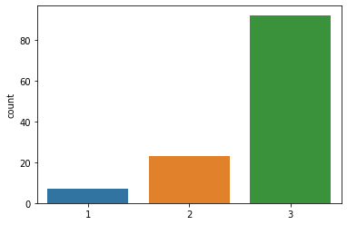

```python
liczba_gatunkow = []
for i in range(0, len(filmy['Gatunek'])):
    liczba_gatunkow.append(filmy['Gatunek'][i].count(",")+1)
liczba_gatunkow = pd.Series(liczba_gatunkow)

sns.countplot(liczba_gatunkow)
```

Jak zostało wspomniane, przeważająca liczba filmów ma przypisane 3 gatunki. Ciekawym może być sprawdzenie, czy liczba gatunków ma przełożenie na średnią ocenę filmu. Możliwe, że filmy bardziej zróżnicowane są ciekawsze dla statystycznego widza.

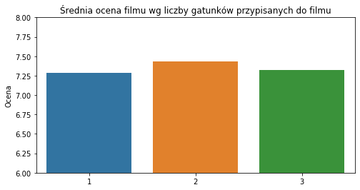

```python
plt.figure(figsize=(8, 4))
sns.barplot(filmy['Ocena'].groupby(liczba_gatunkow).mean().index,
        filmy['Ocena'].groupby(liczba_gatunkow).mean())
plt.ylim(6,8)
plt.title("Średnia ocena filmu wg liczby gatunków przypisanych do filmu")
```

Wykres wskazuje na obecność zależności postawionej w hipotezie, jednak tylko do pewnego stopnia. Filmy z liczbą gatunków większą niż 2 mają trochę niższe noty. Należy zwrócić jednak uwagę na liczebność poszczególnych podgrup: ewentualne różnice mogą wynikać po prostu z mniejszej liczby filmów branych pod uwagę.

W celu dodatkowej analizy, za główny gatunek filmu przyjęty zostanie pierwszy gatunek podany na liście. Uwzględnianie obecnych kombinacji nie byłoby dobrym rozwiązaniem ze względu na mnogość połączeń międzygatunkowych. Sprawdźmy zatem, jak wygląda rozkład gatunków filmów.

```python
gatunek_filmu = filmy['Gatunek'].str.split(',', expand=True)[0]
gatunek_filmu.value_counts()
```

```
Action       40
Drama        22
Adventure    17
Crime        15
Biography    11
Comedy       10
Mystery       3
Horror        2
Thriller      1
Animation     1
Name: 0, dtype: int64
```

Liczebność poszczególnych podgrup wydaje się być w porządku, jednak zawadzają ostatnie wymienione grupy, które mają za mało przedstawicieli. Możliwe, że można im przypisać inny gatunek (nie ten główny), który również obecny będzie na liście.

```python
filmy_grozy_ind = gatunek_filmu[(gatunek_filmu=='Mystery') | (gatunek_filmu=='Horror') | (gatunek_filmu=='Thriller')].index
animacja_ind = gatunek_filmu[gatunek_filmu=='Animation'].index

filmy[['Tytul','Gatunek']].iloc[filmy_grozy_ind]
```

|  | Tytul | Gatunek |
| --- | --- | --- |
| 41 | Enemy | Mystery,Thriller |
| 58 | Death Proof | Thriller |
| 60 | Shutter Island | Mystery,Thriller |
| 91 | The Da Vinci Code | Mystery,Thriller |
| 105 | The Neon Demon | Horror,Thriller |
| 121 | The Conjuring 2 | Horror,Mystery,Thriller |

Wygląda na to, że filmy typu Mystery, Horror i Thriller są zawsze wskazywane jako filmy z kategorii Thriller. Dobrym rozwiązaniem będzie zatem przedstawienie ich jako jednej grupy gatunkowej.

```python
gatunek_filmu.iloc[filmy_grozy_ind] = 'Thriller'

filmy[['Tytul','Gatunek']].iloc[animacja_ind]
```

|  | Tytul | Gatunek |
| --- | --- | --- |
| 32 | Happy Feet | Animation,Comedy,Family |

Z kolei jedyna na liście animacja wskazywana jest również jako komedia, więc i w tym przypadku można dokonać zamiany.

```python
gatunek_filmu.iloc[animacja_ind] = 'Comedy'
```

Po niezbędnych przekształceniach można zbadać średnie oceny dla wskazanych kategorii.

```
(6, 8)
```

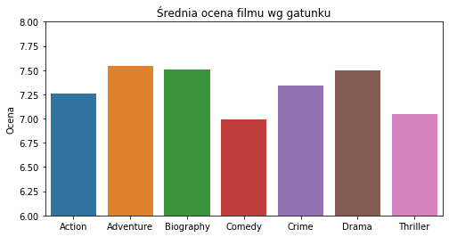

```python
plt.figure(figsize=(8, 4))
sns.barplot(filmy[['Ocena']].groupby(gatunek_filmu).mean().index,
        filmy['Ocena'].groupby(gatunek_filmu).mean())
plt.title("Średnia ocena filmu wg gatunku")
plt.xlabel("")
plt.ylim(6, 8)
```

Widać, że najbardziej cenionymi filmami są filmy przygodowe, biograficzne oraz dramaty. Najniżej z kolei oceniane są komedie oraz filmy grozy. Różnice jednak nie są tak duże, wynosząc maksymalnie 0,5 punktu w skali 1-10. Jak jednak gatunki mają się nie tylko do ocen samych filmów, ale też do ocen aktorów i reżyserów?

```
(6, 8.5)
```

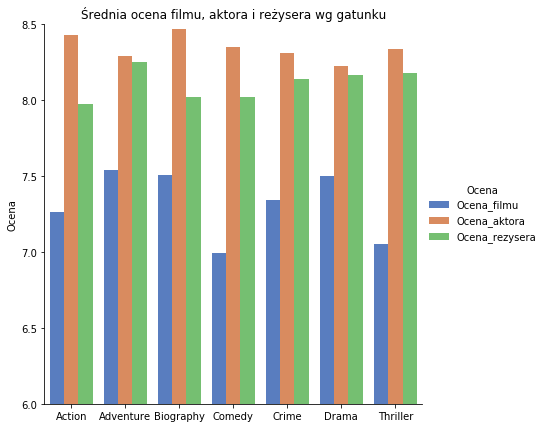

```python
dane = filmy[['Ocena', 'Ocena_aktora', 'Ocena_rezysera']].groupby(gatunek_filmu).mean()
dane['Gatunek'] = dane.index
dane = pd.melt(dane, id_vars=['Gatunek'])
dane['variable'] = dane['variable'].replace({'Ocena': 'Ocena_filmu'})
dane = dane.rename({'variable':'Ocena'}, axis='columns')
sns.catplot(x="Gatunek", y="value", hue="Ocena", data=dane,
                height=6, kind="bar", palette="muted")
plt.title("Średnia ocena filmu, aktora i reżysera wg gatunku")
plt.xlabel("")
plt.ylabel("Ocena")
plt.ylim(6, 8.5)
```

Komedie wypadają słabo jeśli chodzi o całościowe ujęcie, jednak średnia ocena aktorów jest tam jedna z najwyższych (tak kolorowo nie jest jednak w przypadku reżysera). Ciekawi wysoka pozycja thrillerów w ocenie aktora oraz reżysera. Kategorią filmów, które cały czas trzymają wysoki poziom, są filmy przygodowe. Tam też najmniejsze są różnice między oceną gry aktorskiej a reżyserii filmu. Największe różnice występują w filmach akcji oraz biografiach.

Ciekawym do zbadania może być zagadnienie międzygatunkowości aktorów i reżyserów. Czy są osoby, które specjalizują się wyłącznie w jednym gatunku filmów? Albo wręcz przeciwnie, uwielbiają zmiany?

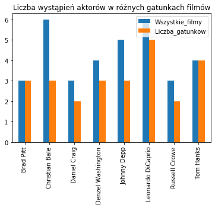

```python
filmy_gatunki = filmy.copy()
filmy_gatunki['Gatunek'] = gatunek_filmu
multi_aktorzy = np.array(filmy_gatunki['Aktor'].value_counts()[filmy_gatunki['Aktor'].value_counts()>1].index)
filmy_multi_aktorow = filmy_gatunki[filmy_gatunki['Aktor'].isin(multi_aktorzy)]
multi_aktorzy_gatunki = pd.crosstab(filmy_multi_aktorow['Aktor'], filmy_multi_aktorow['Gatunek'])
multi_aktorzy_gatunki.astype(bool).sum(axis=1).sort_values(ascending=False)

wszystkie_filmy = filmy_multi_aktorow['Aktor'].value_counts().sort_index()
liczba_gatunkow = multi_aktorzy_gatunki.astype(bool).sum(axis=1).sort_index()
aktorzy_vs_gatunki = pd.DataFrame({'Wszystkie_filmy':wszystkie_filmy,
                                  'Liczba_gatunkow':liczba_gatunkow})

plt.figure(figsize=(8, 4))
aktorzy_vs_gatunki[aktorzy_vs_gatunki['Wszystkie_filmy']>2].plot(
        y=['Wszystkie_filmy','Liczba_gatunkow'], kind="bar")
plt.title("Liczba wystąpień aktorów w różnych gatunkach filmów")
plt.xlabel("")
plt.ylabel("")
```

Na powyższym wykresie ujęci zostali aktorzy, którzy grali w największej ilości filmów. Z wykresu tego wynika, że wraz ze wzrostem dorobku filmowego wzrasta także chęć do eksperymentowania z różnymi gatunkami (rekordzistą jest tu Leonardo DiCaprio, który na 6 filmów brał udział w produkcji filmów z 5 różnych kategorii; warci uwagi są Brad Pitt i Tom Hanks, którzy za każdym razem biorą na warsztat coś innego). Wyjątkiem jest tu Christian Bale, który na 6 filmów ma tylko 3 gatunki. Rzućmy okiem na jego dorobek filmowy.

```python
filmy[['Tytul','Ocena','Gatunek']][filmy['Aktor'] == 'Christian Bale']
```

|  | Tytul | Ocena | Gatunek |
| --- | --- | --- | --- |
| 13 | Exodus: Gods and Kings | 6.0 | Action,Adventure,Drama |
| 14 | Public Enemies | 7.0 | Biography,Crime,Drama |
| 15 | The Dark Knight Rises | 8.5 | Action,Thriller |
| 16 | The Big Short | 7.8 | Biography,Comedy,Drama |
| 17 | The Prestige | 8.5 | Drama,Mystery,Sci-Fi |
| 18 | The Dark Knight | 9.0 | Action,Crime,Drama |

Zdecydowanie dominują filmy akcji, a mianowicie rola Batmana w obu częściach Mrocznego Rycerza.

Jak wygląda podobne podsumowanie dla reżyserów?

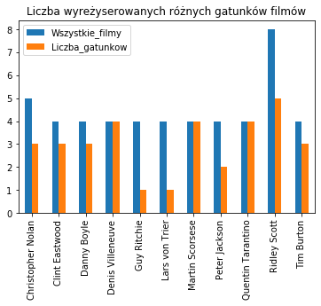

```python
multi_rezyserzy = np.array(filmy_gatunki['Rezyser'].value_counts()[filmy_gatunki['Rezyser'].value_counts()>1].index)
filmy_multi_rezyserow = filmy_gatunki[filmy_gatunki['Rezyser'].isin(multi_rezyserzy)]
multi_rezyserzy_gatunki = pd.crosstab(filmy_multi_rezyserow['Rezyser'], filmy_multi_rezyserow['Gatunek'])
multi_rezyserzy_gatunki.astype(bool).sum(axis=1).sort_values(ascending=False)

wszystkie_filmy = filmy_multi_rezyserow['Rezyser'].value_counts().sort_index()
liczba_gatunkow = multi_rezyserzy_gatunki.astype(bool).sum(axis=1).sort_index()
rezyserzy_vs_gatunki = pd.DataFrame({'Wszystkie_filmy':wszystkie_filmy,
                                  'Liczba_gatunkow':liczba_gatunkow})

rezyserzy_vs_gatunki[rezyserzy_vs_gatunki['Wszystkie_filmy']>3].plot(
        y=['Wszystkie_filmy','Liczba_gatunkow'], kind="bar")
plt.title("Liczba wyreżyserowanych różnych gatunków filmów")
plt.xlabel("")
plt.ylabel("")
```

Wygląda na to, że również reżyserzy wraz ze wzrostem doświadczenia sięgają po kolejne gatunki filmowe (Denis Villeneuve i Quentin Tarantino za każdym razem wybierali coś nowego; Ridley Scott może poszczycić się największą liczbą gatunków na koncie). Wyjątek można zauważyć w przypadku dwóch reżyserów: Guya Ritchiego i Larsa von Triera (nazwisko znajome, pojawiło się już przy okazji jednej z aktorek).

```python
filmy[['Tytul','Ocena','Gatunek']][filmy['Rezyser'] == 'Guy Ritchie' ]
```

|  | Tytul | Ocena | Gatunek |
| --- | --- | --- | --- |
| 34 | RocknRolla | 7.3 | Action,Crime,Thriller |
| 36 | The Man from U.N.C.L.E. | 7.3 | Action,Adventure,Comedy |
| 77 | Sherlock Holmes: A Game of Shadows | 7.5 | Action,Adventure,Crime |
| 78 | Sherlock Holmes | 7.6 | Action,Adventure,Crime |

```python
filmy[['Tytul','Ocena','Gatunek']][filmy['Rezyser'] == 'Lars von Trier']
```

|  | Tytul | Ocena | Gatunek |
| --- | --- | --- | --- |
| 99 | Antichrist | 6.6 | Drama,Horror |
| 103 | Nymphomaniac: Vol. II | 6.7 | Drama |
| 104 | Nymphomaniac: Vol. I | 7.0 | Drama |
| 111 | Melancholia | 7.1 | Drama |

Guy Ritchie upodobał sobie filmy akcji, z kolei Lars von Trier celuje w dramaty.

A co powiedzieć może nam kolejna zmienna?

## 2.5 Dlugosc

Dobrym początkiem będzie zbadanie rozkładu długości filmów. Jakie filmy dominują w zebranej bazie danych?

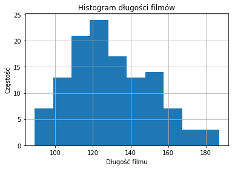

```python
filmy['Dlugosc'].hist(bins=10)
plt.title("Histogram długości filmów")
plt.xlabel('Długość filmu')
plt.ylabel('Częstość')
```

W biorze danych definitywnie dominują filmy o długości około 2 godzin, natomiast rekordziści sięgają nawet powyżej 3 godzin. Jest też pewna liczba filmów, które nie przekraczają 100 minut. Czy jednak możemy mówić tu o outlierach?

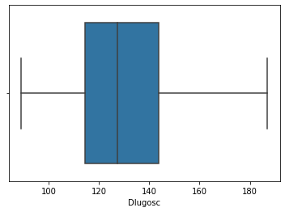

```python
sns.boxplot(filmy['Dlugosc'])
```

Okazuje się, że nie. Żaden z filmów nie odstaje na tyle, aby uznać go za outliera.

Czy długi film może nudzić widza? A może krótki film pozostawia niedosyt? Zagadnienie to najlepiej zbada odpowiedni wykres.

```
array([[1.        , 0.28175329],
       [0.28175329, 1.        ]])
```

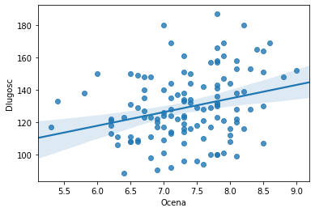

```python
sns.regplot(filmy['Ocena'], filmy['Dlugosc'])
np.corrcoef(filmy['Ocena'], filmy['Dlugosc'])
```

Okazuje się, że ani jedno, ani drugie. Długość filmu ma małe znaczenie dla oceny filmu. Najkrótsze filmy są jednak oceniane nieco gorzej niż filmy najdłuższe.

A co na to zmienna Ocena_aktora?

```
array([[1.        , 0.29396402],
       [0.29396402, 1.        ]])
```

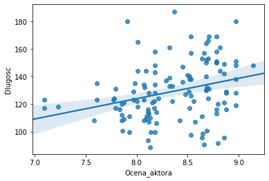

```python
sns.regplot(filmy['Ocena_aktora'], filmy['Dlugosc'])
np.corrcoef(filmy['Ocena_aktora'], filmy['Dlugosc'])
```

Nie widać w tym przypadku, aby dłuższy film miał większy związek z obecnością dobrego aktora/aktorki. A może zależność taka spełni się w przypadku reżysera? O ile zagranie przez aktora w dłuższym filmie oznacza po prostu większą liczbę godzin na planie, tak dla reżysera, moim zdaniem, jest to większe wyzwanie logistyczne.

```
array([[1.        , 0.49251141],
       [0.49251141, 1.        ]])
```

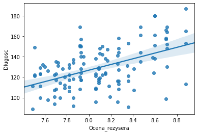

```python
sns.regplot(filmy['Ocena_rezysera'], filmy['Dlugosc'])
np.corrcoef(filmy['Ocena_rezysera'], filmy['Dlugosc'])
```

Rzeczywiście, korelacja jest tu już znacznie wyraźniejsza. Można domyślać się, że po długie filmy sięgają w większości wyłącznie bardziej doświadczeni i uhonorowani reżyserzy.

Ciekawym pytaniem jest, czy istnieją reżyserzy, którzy upodobali sobie szczególnie długie filmy? Za szczególnie długie filmy uznane zostaną te produkcje, które długością przekraczają trzeci kwartyl.

```python
filmy['Ocena_rezysera'].describe()
```

[output not shown]

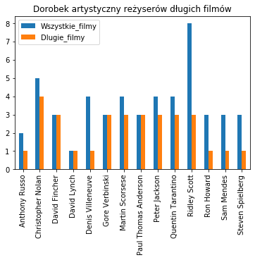

```python
rezyserzy_dlugich_filmow = filmy[filmy['Dlugosc']>=143.75]['Rezyser'].value_counts().sort_index()
filmy_dlugich_rezyserow = filmy[filmy['Rezyser'].isin(rezyserzy_dlugich_filmow.index)]
filmy_dlugich_rezyserow_suma = filmy_dlugich_rezyserow['Rezyser'].value_counts().sort_index()
wszystkie_filmy_dlugich = pd.concat([rezyserzy_dlugich_filmow, filmy_dlugich_rezyserow_suma], axis=1)
wszystkie_filmy_dlugich.columns = ['Dlugie_filmy', 'Wszystkie_filmy']

wszystkie_filmy_dlugich.plot(y=['Wszystkie_filmy','Dlugie_filmy'], kind="bar")
plt.title("Dorobek artystyczny reżyserów długich filmów")
plt.xlabel("")
plt.ylabel("")
```

Widoczni są reżyserzy, któzy nakręcili wyłącznie długie filmy: Gore Verbinski, Paul Thomas Anderson, David Flincher. W bezwzględnych wartościach prowadzi Christopher Nolan. Ciekawie jawi się postać Davida Lyncha, który posiada wyłącznie jeden film i jest to film długi. Cały czas jednak należy pamiętać o losowości omawianych danych.

```python
filmy[filmy['Rezyser'] == 'David Lynch']
```

|  | Aktor | Rezyser | Tytul | Gatunek | Dlugosc | Ocena | Glosy | Box.office | Ocena_rezysera | Ocena_aktora | Oscary |
| --- | --- | --- | --- | --- | --- | --- | --- | --- | --- | --- | --- |
| 112 | Laura Dern | David Lynch | Inland Empire | Drama,Mystery,Thriller | 180 | 7.0 | 44227 | 4.04 | 8.6 | 7.91 | 0 |

Wiemy już którzy reżyserzy kręcą głównie długie filmy, a które gatunki są najczęśćiej najdłuższe?

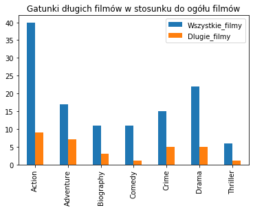

```python
gatunki_dlugich_filmow = filmy_gatunki[filmy_gatunki['Dlugosc']>=143.75]['Gatunek'].value_counts().sort_index()
gatunki_suma = filmy_gatunki['Gatunek'].value_counts().sort_index()
gatunki_dlugich = pd.concat([gatunki_dlugich_filmow, gatunki_suma], axis=1)
gatunki_dlugich.columns = ['Dlugie_filmy', 'Wszystkie_filmy']

gatunki_dlugich.plot(y=['Wszystkie_filmy','Dlugie_filmy'], kind="bar")
plt.title("Gatunki długich filmów w stosunku do ogółu filmów")
plt.xlabel("")
plt.ylabel("")
```

Jeśli popatrzeć na udział procentowy, na pierwszym miejscu uplasują sięfilmy przygodowe. Jest to zgodne z intuicją, fascynująca przeprawa może zająć naprawdę dużo czasu. Na ostatnim miejscu uplasują się natomiast komedie - śmiech to zdrowie, ale wszystko ma swoje granice.

SKoro zbadane zostały gatunki dla najdłuższych filmów, ciekawe może być zajrzenie do filmów najkrótszych (wartość poniżej pierwszego kwartyla).

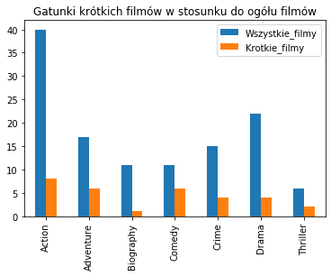

```python
gatunki_krotkich_filmow = filmy_gatunki[filmy_gatunki['Dlugosc']<=114.5]['Gatunek'].value_counts().sort_index()
gatunki_krotkich = pd.concat([gatunki_krotkich_filmow, gatunki_suma], axis=1)
gatunki_krotkich.columns = ['Krotkie_filmy', 'Wszystkie_filmy']

gatunki_krotkich.plot(y=['Wszystkie_filmy','Krotkie_filmy'], kind="bar")
plt.title("Gatunki krótkich filmów w stosunku do ogółu filmów")
plt.xlabel("")
plt.ylabel("")
```

Tym razem filmy komediowe są na szczycie, jednak to nie filmy przygodowe przegrywająto starcie, a filmy biograficzne - biorąc na warsztat ciekawą osobowość nie sposób zamknąć się w tak krótkich ramach czasowych.

Długie, krótkie... A co ze średnią? Otóż biegnę z odpowiedzią!

```
(80, 140)
```

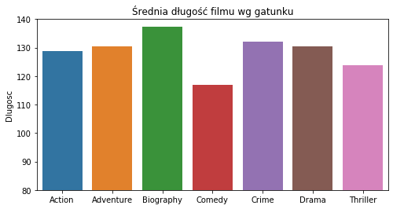

```python
plt.figure(figsize=(8, 4))
sns.barplot(filmy[['Dlugosc']].groupby(gatunek_filmu).mean().index,
        filmy['Dlugosc'].groupby(gatunek_filmu).mean())
plt.title("Średnia długość filmu wg gatunku")
plt.xlabel("")
plt.ylim(80, 140)
```

Zauważyć można, że pomimo największej obecności filmów przygodowych w rekordzistach, średnio najdłuższe filmy to filmy biograficzne oraz kryminalne i dramaty. Przygodowe filmy są dopiero na późniejszej lokacie. Z kolei komedie są średnio najkrótsze.

Czas na zbadanie popularności filmów.